Biologi

# Dafnier og koffein

Laboratorieøvelse

**Dato:** ____________________ **Gruppe / navne:** ____________________________________________

## Om øvelsen

I dag skal I undersøge, hvordan koffein påvirker en dafnies hjerterytme. Dafnien er gennemsigtig, så I kan se dens hjerte slå direkte i mikroskopet, mens I tilsætter kaffeopløsninger med stigende koncentration.

## Fremgangsmåde

### A. Fremstilling af kaffeopløsninger (fortyndingsrække)

1. Opløs 2 g instant kaffe i 100 mL vand. Det giver en stamopløsning på 600 mg koffein/L (ud fra et gennemsnitligt koffeinindhold på 30 mg pr. gram instant kaffe).
2. Lav en fortyndingsrække ved at halvere koncentrationen i hvert trin: bland 50 mL af den foregående opløsning med 50 mL vand for at få den næste. Fortsæt, til I har seks opløsninger: 600, 300, 150, 75, 37,5 og 18,75 mg/L.
3. Mærk hvert glas tydeligt med koncentrationen.

### B. Dafniens hjerterytme uden og med koffein

1. Fang en dafnie forsigtigt med en pipette med afklippet spids, og læg den på et objektglas med 2 dråber vand. Læg et dækglas over.
2. Indstil mikroskopet, så I tydeligt kan se dafnien og dens hjerte slå. Tegn den, eller tag et billede.

   Hjertet sidder på “ryggen” af dafnien, se Figur 1.

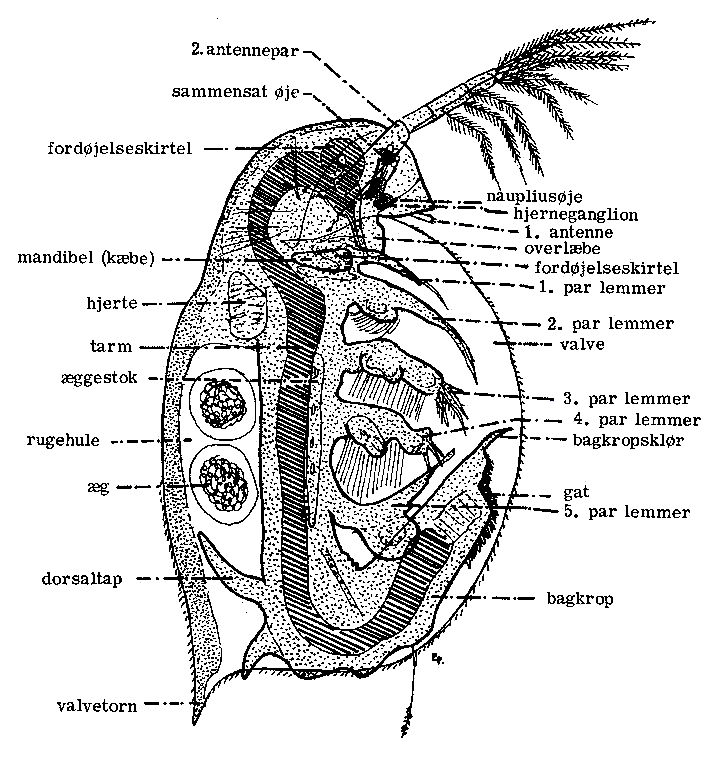

   Figur 1: Dafniens indre bygning, med hjertet markeret. Efter Flemming Petersen, dafnier.dk (bearbejdet).

3. Tæl hjerteslagene i 15 sekunder, og gang med 4. Gør det 3 gange, og notér resultaterne i skemaet under “0 mg/L”.
4. Sluk lyset i mikroskopet, så snart I ikke kigger — for meget lys/varme fra lyskilden skader dafnien og forstyrrer resultatet.
5. Tag dækglasset af, og tilsæt et par dråber af opløsningen med den laveste koffeinkoncentration (18,75 mg/L). Læg dækglasset på igen.
6. Se i mikroskopet, hvordan dafniens hjerte reagerer, og tæl hjerteslagene igen som i trin 3.
7. Gentag trin 4–6 med de næste koncentrationer i stigende rækkefølge, indtil I har afprøvet alle seks.

**TipTip**

Hold igen med lyset mellem tællingerne — det er den hyppigste årsag til, at dafnien tager skade før tid. Har I flere dafnier i kulturen, så skift til en frisk en, hvis den, I er i gang med, ser ud til at dø undervejs.

**NoteMaterialer (pr. gruppe)**

- Lysmikroskop
- Objektglas (evt. hul-objektglas) og dækglas
- Dafnier fra kulturkar
- Pipette med afklippet spids (til at fange dafnier skånsomt)
- Instant kaffe og vand
- 6 mærkede glas til fortyndingsrækken
- Målebæger eller målecylinder (100 mL)
- Ur eller stopur
- Blyant og papir til tegninger

## Registrering af målinger

Tabel 1: Antal hjerteslag pr. minut hos dafnien ved stigende koffeinkoncentration.

| Koffeinkoncentration | Måling 1 | Måling 2 | Måling 3 | Gennemsnit | Noter |
| --- | --- | --- | --- | --- | --- |
| 0 mg/L (uden koffein) |  |  |  |  |  |
| 18,75 mg/L |  |  |  |  |  |
| 37,5 mg/L |  |  |  |  |  |
| 75 mg/L |  |  |  |  |  |
| 150 mg/L |  |  |  |  |  |
| 300 mg/L |  |  |  |  |  |
| 600 mg/L |  |  |  |  |  |

## Databehandling

1. Beregn for hver koncentration gennemsnittet af de tre tællinger, og skriv det i Tabel 1:

$$\text{Gennemsnitlig puls} = \frac{\text{måling 1} + \text{måling 2} + \text{måling 3}}{3}$$

2. Beregn for hver koncentration, hvor mange procent pulsen har ændret sig i forhold til pulsen uden koffein:

$$\text{Ændring (\%)} = \frac{\text{puls med koffein} - \text{puls ved 0 mg/L}}{\text{puls ved 0 mg/L}} \cdot 100$$

Tabel 2: Udregnet gennemsnit og procentvis ændring af pulsen.

| Koffeinkoncentration (mg/L) | 0 | 18,75 | 37,5 | 75 | 150 | 300 | 600 |
| --- | --- | --- | --- | --- | --- | --- | --- |
| Gennemsnitlig puls (slag/min) |  |  |  |  |  |  |  |
| Ændring i forhold til 0 mg/L (%) | 0 |  |  |  |  |  |  |

3. Lav en graf (fx i Excel) med koffeinkoncentrationen på x-aksen og den gennemsnitlige puls på y-aksen. Da koncentrationen fordobles fra trin til trin, kan det være en fordel også at prøve en logaritmisk x-akse.
4. Beskriv grafens form: Stiger pulsen jævnt med koncentrationen, flader den ud, eller falder den igen ved de højeste koncentrationer? Ved hvilken koncentration ses den største virkning?
5. Sammenlign jeres kurve med en eller to andre gruppers. Ligner de hinanden?

## Journalspørgsmål

1. Hvad var jeres hypotese, og blev den be- eller afkræftet af resultaterne?
2. Koffein virker stimulerende på nervesystemet og hjertet. Forklar ud fra jeres graf, hvordan dafniens hjerte reagerer på koffein, og diskutér, hvad der kan ske ved de højeste koncentrationer.
3. Dafnier er vekselvarme. Hvorfor er det vigtigt at slukke lyset i mikroskopet mellem tællingerne, og hvordan ville en stigende temperatur påvirke jeres resultater?
4. I bruger den samme dafnie til alle koncentrationerne. Hvilke fordele og ulemper har det i forhold til at bruge en ny dafnie til hver koncentration? Hvordan kan rækkefølgen af koncentrationerne påvirke resultatet?
5. En kop kaffe indeholder ca. 60 mg koffein. Hvor mange mg koffein pr. liter blod ville det svare til, hvis koffeinen fordelte sig i et menneskes ca. 5 L blod, og hvordan ligger det i forhold til de koncentrationer, I har brugt? Diskutér, om man kan overføre resultaterne fra dafnier til mennesker.
6. Hvilke fejlkilder var der i forsøget (fx tælling af hurtige hjerteslag, dafniens tilstand, varme fra lyset), og hvordan påvirker de konklusionen?